# Digitalization in the workplace: Hidden cost of control? - Data Analysis

### Explore data

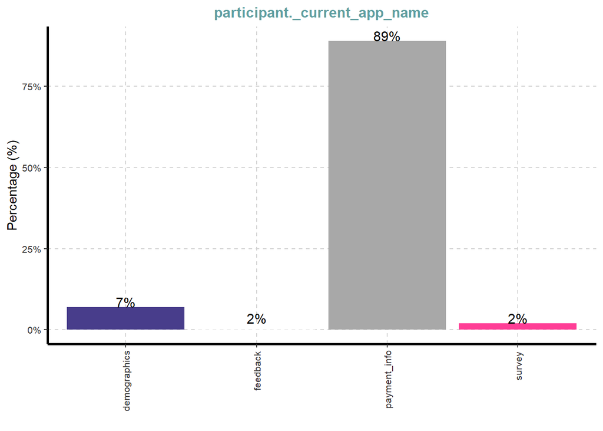

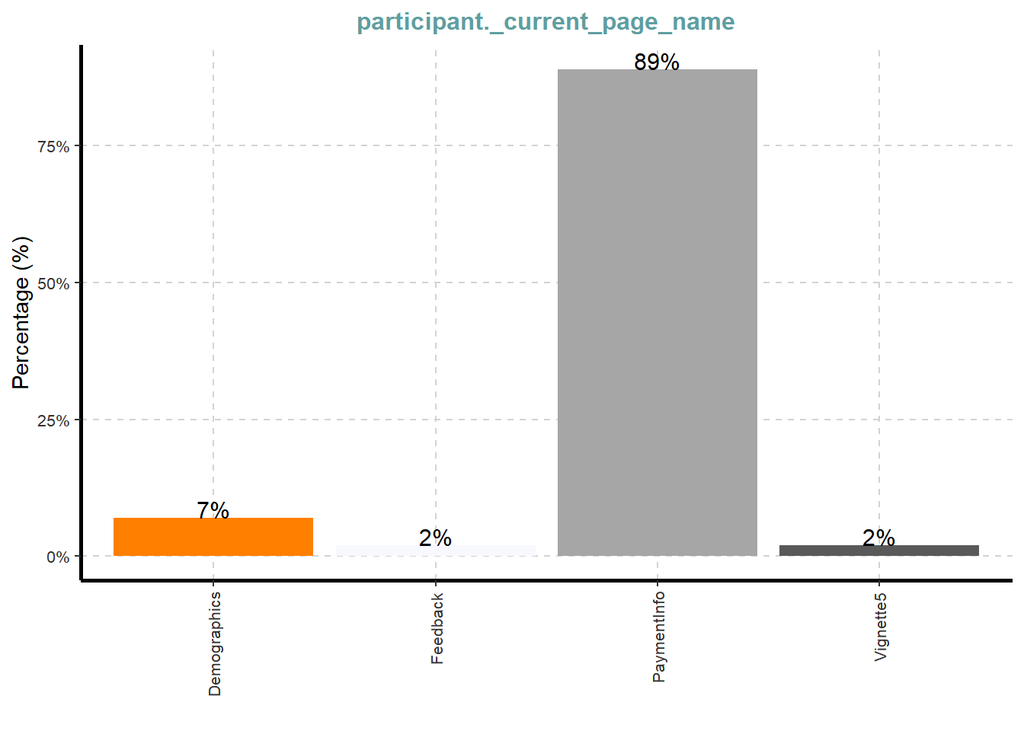

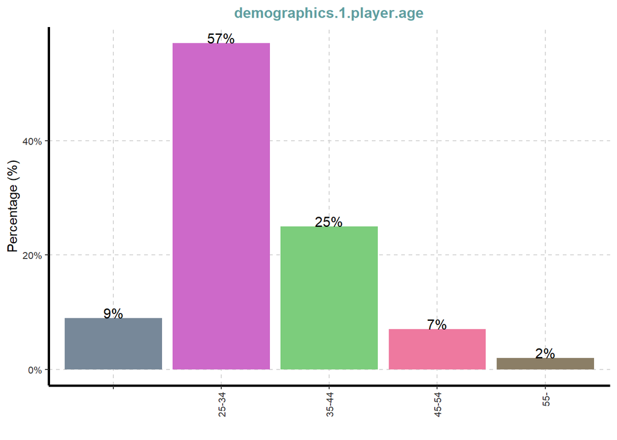

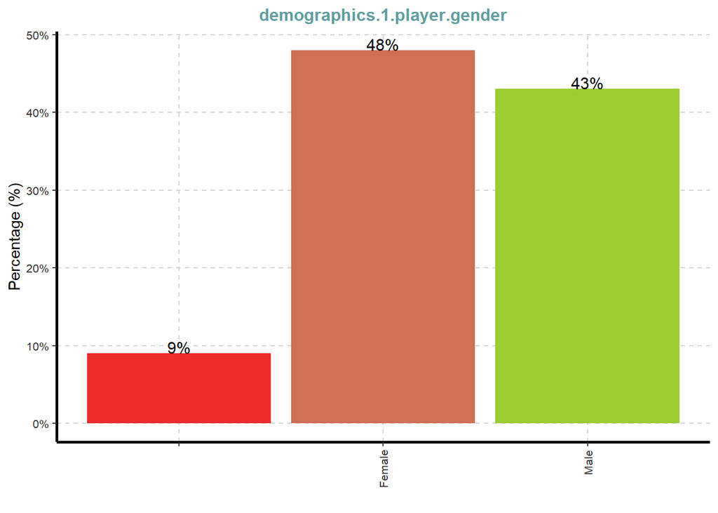

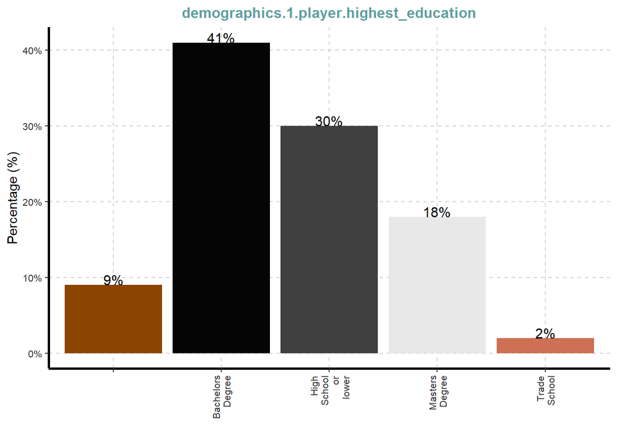

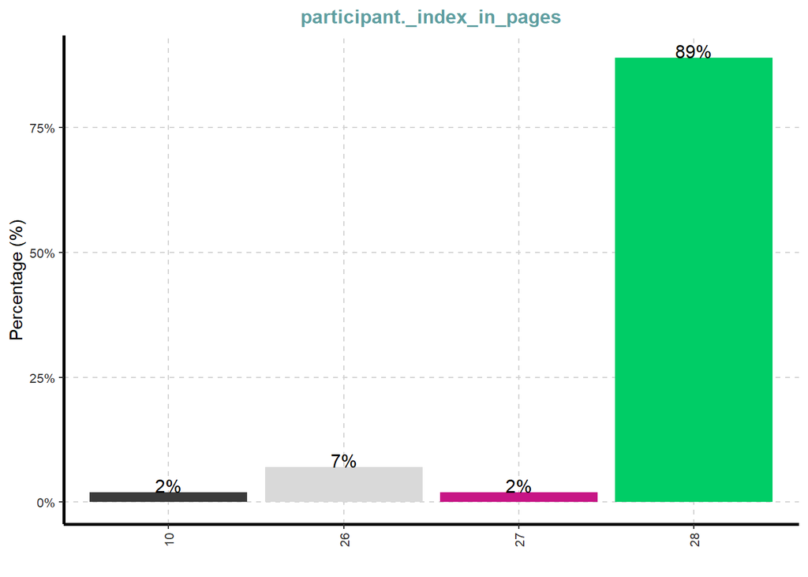

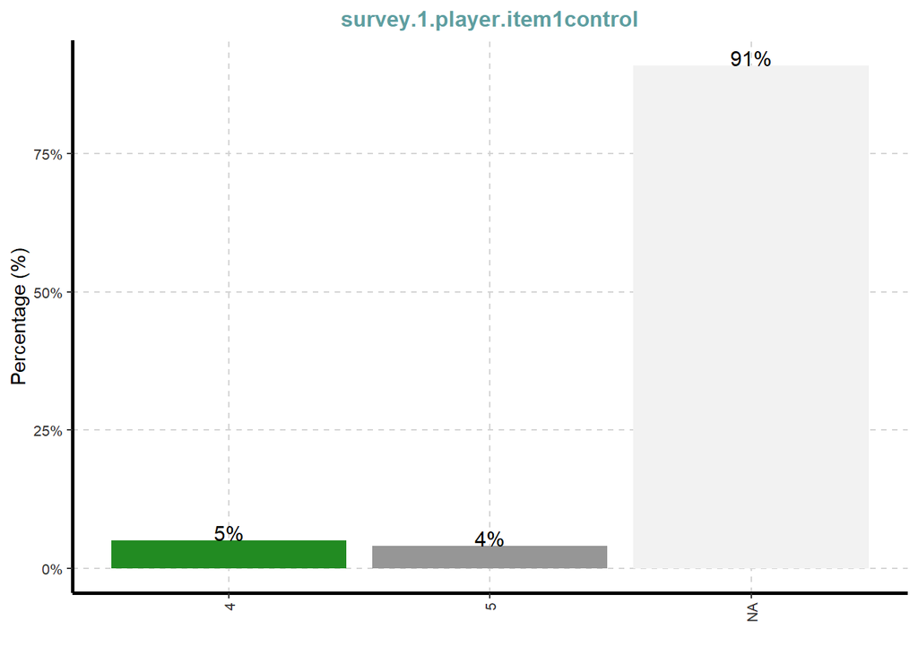

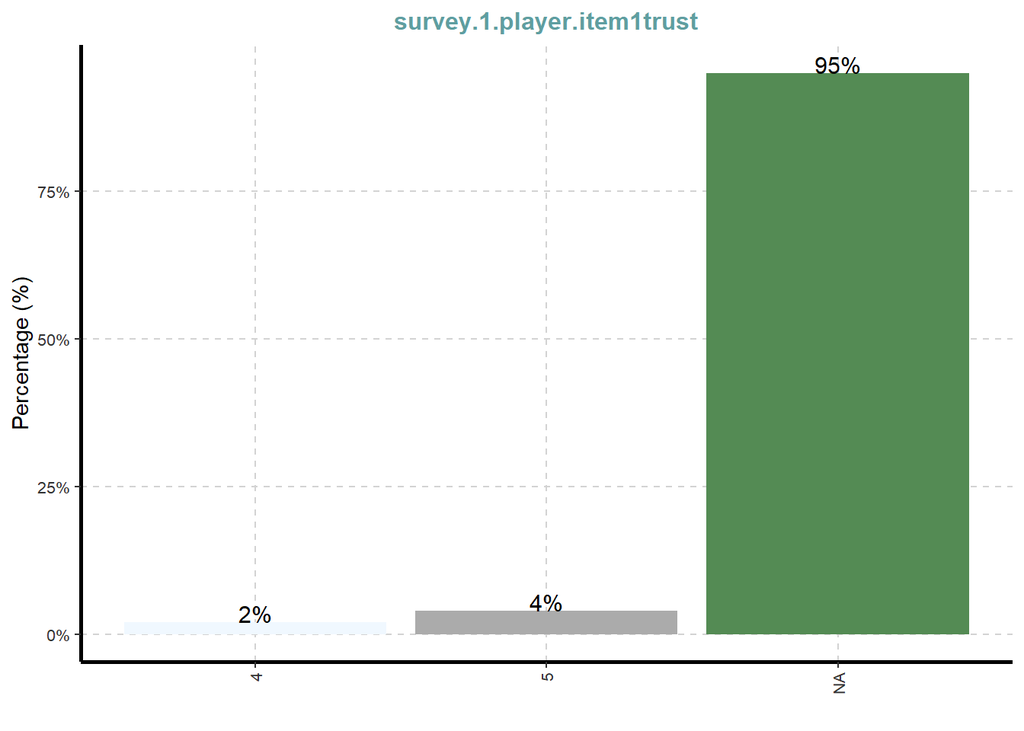

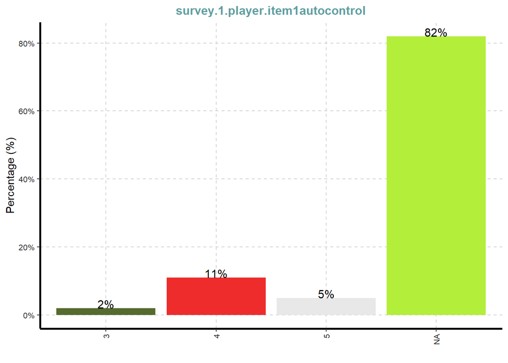

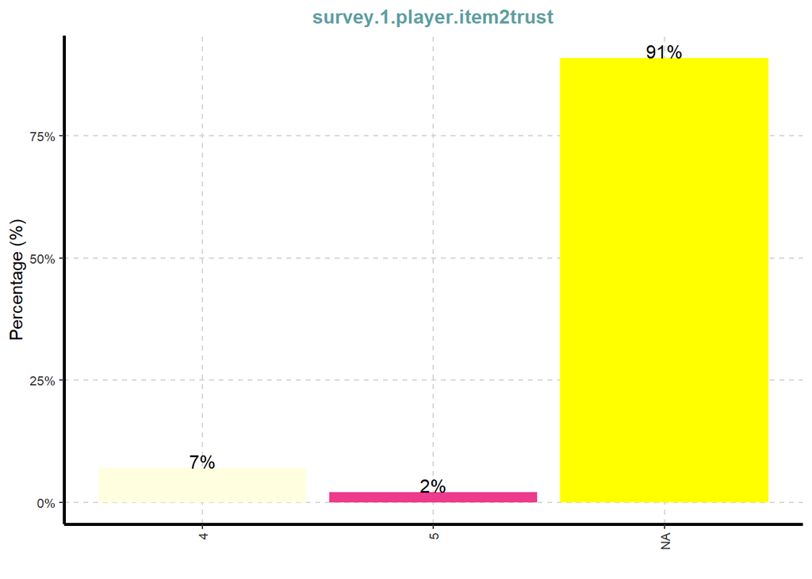

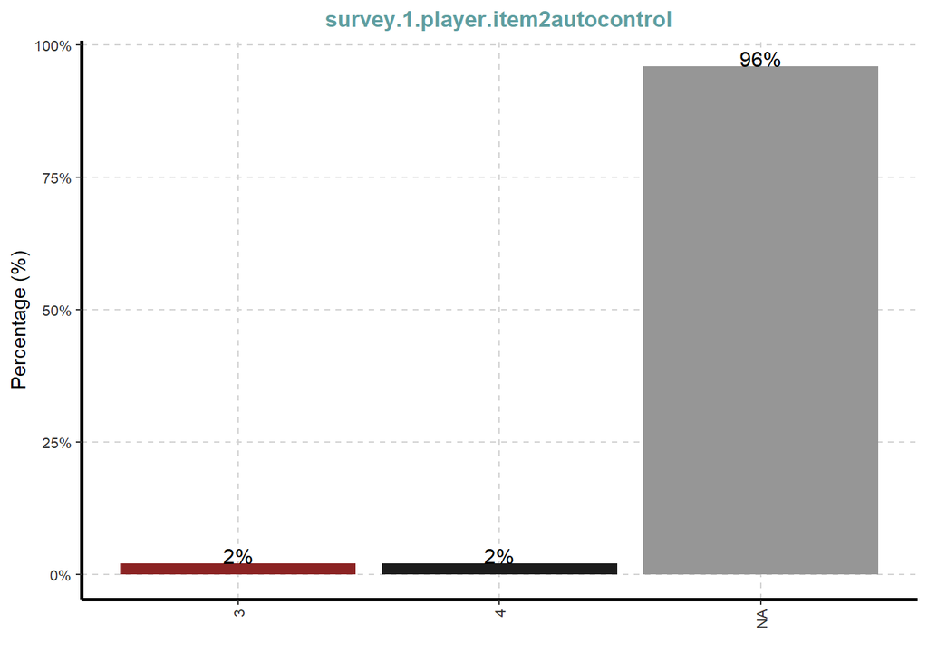

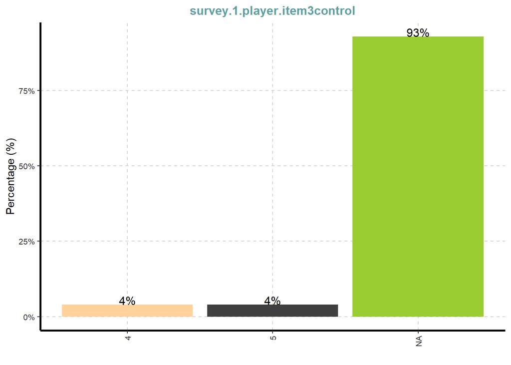

[49 more figures not shown]

```r
ExpCatViz(survey_df)
```

Some insight that can be drawn:

- female predominance in gender data.
- the majority of participants is in the second youngest age group: 25-34. Also, no one is aged 18-24.
- the majority of participants has a bachelor’s degree (41%) with a high school or lower on the second place (30%).
- the majority of participants had between 3 and 4 years of work experience.

### Prepare data

Let us reform the data by placing all trust, control, autocontrol and monitoring responses in respective vectors for statistical testing.

```r
trust <- c()
trust <- c(trust, survey_df$survey.1.player.item1trust[!is.na(survey_df$survey.1.player.item1trust)])
trust <- c(trust, survey_df$survey.1.player.item2trust[!is.na(survey_df$survey.1.player.item2trust)])
trust <- c(trust, survey_df$survey.1.player.item3trust[!is.na(survey_df$survey.1.player.item3trust)])
trust <- c(trust, survey_df$survey.1.player.item4trust[!is.na(survey_df$survey.1.player.item4trust)])
trust <- c(trust, survey_df$survey.1.player.item5trust[!is.na(survey_df$survey.1.player.item5trust)])
trust <- c(trust, survey_df$survey.2.player.item1trust[!is.na(survey_df$survey.2.player.item1trust)])
trust <- c(trust, survey_df$survey.2.player.item2trust[!is.na(survey_df$survey.2.player.item2trust)])
trust <- c(trust, survey_df$survey.2.player.item3trust[!is.na(survey_df$survey.2.player.item3trust)])
trust <- c(trust, survey_df$survey.2.player.item4trust[!is.na(survey_df$survey.2.player.item4trust)])
trust <- c(trust, survey_df$survey.2.player.item5trust[!is.na(survey_df$survey.2.player.item5trust)])
trust <- c(trust, survey_df$survey.3.player.item1trust[!is.na(survey_df$survey.3.player.item1trust)])
trust <- c(trust, survey_df$survey.3.player.item2trust[!is.na(survey_df$survey.3.player.item2trust)])
trust <- c(trust, survey_df$survey.3.player.item3trust[!is.na(survey_df$survey.3.player.item3trust)])
trust <- c(trust, survey_df$survey.3.player.item4trust[!is.na(survey_df$survey.3.player.item4trust)])
trust <- c(trust, survey_df$survey.3.player.item5trust[!is.na(survey_df$survey.3.player.item5trust)])
trust <- c(trust, survey_df$survey.4.player.item1trust[!is.na(survey_df$survey.4.player.item1trust)])
trust <- c(trust, survey_df$survey.4.player.item2trust[!is.na(survey_df$survey.4.player.item2trust)])
trust <- c(trust, survey_df$survey.4.player.item3trust[!is.na(survey_df$survey.4.player.item3trust)])
trust <- c(trust, survey_df$survey.4.player.item4trust[!is.na(survey_df$survey.4.player.item4trust)])
trust <- c(trust, survey_df$survey.4.player.item5trust[!is.na(survey_df$survey.4.player.item5trust)])
trust <- c(trust, survey_df$survey.5.player.item1trust[!is.na(survey_df$survey.5.player.item1trust)])
trust <- c(trust, survey_df$survey.5.player.item2trust[!is.na(survey_df$survey.5.player.item2trust)])
trust <- c(trust, survey_df$survey.5.player.item3trust[!is.na(survey_df$survey.5.player.item3trust)])
trust <- c(trust, survey_df$survey.5.player.item4trust[!is.na(survey_df$survey.5.player.item4trust)])
trust <- c(trust, survey_df$survey.5.player.item5trust[!is.na(survey_df$survey.5.player.item5trust)])
```

```r
control <- c()
control <- c(control, survey_df$survey.1.player.item1control[!is.na(survey_df$survey.1.player.item1control)])
control <- c(control, survey_df$survey.1.player.item2control[!is.na(survey_df$survey.1.player.item2control)])
control <- c(control, survey_df$survey.1.player.item3control[!is.na(survey_df$survey.1.player.item3control)])
control <- c(control, survey_df$survey.1.player.item4control[!is.na(survey_df$survey.1.player.item4control)])
control <- c(control, survey_df$survey.1.player.item5control[!is.na(survey_df$survey.1.player.item5control)])
control <- c(control, survey_df$survey.2.player.item1control[!is.na(survey_df$survey.2.player.item1control)])
control <- c(control, survey_df$survey.2.player.item2control[!is.na(survey_df$survey.2.player.item2control)])
control <- c(control, survey_df$survey.2.player.item3control[!is.na(survey_df$survey.2.player.item3control)])
control <- c(control, survey_df$survey.2.player.item4control[!is.na(survey_df$survey.2.player.item4control)])
control <- c(control, survey_df$survey.2.player.item5control[!is.na(survey_df$survey.2.player.item5control)])
control <- c(control, survey_df$survey.3.player.item1control[!is.na(survey_df$survey.3.player.item1control)])
control <- c(control, survey_df$survey.3.player.item2control[!is.na(survey_df$survey.3.player.item2control)])
control <- c(control, survey_df$survey.3.player.item3control[!is.na(survey_df$survey.3.player.item3control)])
control <- c(control, survey_df$survey.3.player.item4control[!is.na(survey_df$survey.3.player.item4control)])
control <- c(control, survey_df$survey.3.player.item5control[!is.na(survey_df$survey.3.player.item5control)])
control <- c(control, survey_df$survey.4.player.item1control[!is.na(survey_df$survey.4.player.item1control)])
control <- c(control, survey_df$survey.4.player.item2control[!is.na(survey_df$survey.4.player.item2control)])
control <- c(control, survey_df$survey.4.player.item3control[!is.na(survey_df$survey.4.player.item3control)])
control <- c(control, survey_df$survey.4.player.item4control[!is.na(survey_df$survey.4.player.item4control)])
control <- c(control, survey_df$survey.4.player.item5control[!is.na(survey_df$survey.4.player.item5control)])
control <- c(control, survey_df$survey.5.player.item1control[!is.na(survey_df$survey.5.player.item1control)])
control <- c(control, survey_df$survey.5.player.item2control[!is.na(survey_df$survey.5.player.item2control)])
control <- c(control, survey_df$survey.5.player.item3control[!is.na(survey_df$survey.5.player.item3control)])
control <- c(control, survey_df$survey.5.player.item4control[!is.na(survey_df$survey.5.player.item4control)])
control <- c(control, survey_df$survey.5.player.item5control[!is.na(survey_df$survey.5.player.item5control)])
```

```r
autocontrol <- c()
autocontrol <- c(autocontrol, survey_df$survey.1.player.item1autocontrol[!is.na(survey_df$survey.1.player.item1autocontrol)])
autocontrol <- c(autocontrol, survey_df$survey.1.player.item2autocontrol[!is.na(survey_df$survey.1.player.item2autocontrol)])
autocontrol <- c(autocontrol, survey_df$survey.1.player.item3autocontrol[!is.na(survey_df$survey.1.player.item3autocontrol)])
autocontrol <- c(autocontrol, survey_df$survey.1.player.item4autocontrol[!is.na(survey_df$survey.1.player.item4autocontrol)])
autocontrol <- c(autocontrol, survey_df$survey.1.player.item5autocontrol[!is.na(survey_df$survey.1.player.item5autocontrol)])
autocontrol <- c(autocontrol, survey_df$survey.2.player.item1autocontrol[!is.na(survey_df$survey.2.player.item1autocontrol)])
autocontrol <- c(autocontrol, survey_df$survey.2.player.item2autocontrol[!is.na(survey_df$survey.2.player.item2autocontrol)])
autocontrol <- c(autocontrol, survey_df$survey.2.player.item3autocontrol[!is.na(survey_df$survey.2.player.item3autocontrol)])
autocontrol <- c(autocontrol, survey_df$survey.2.player.item4autocontrol[!is.na(survey_df$survey.2.player.item4autocontrol)])
autocontrol <- c(autocontrol, survey_df$survey.2.player.item5autocontrol[!is.na(survey_df$survey.2.player.item5autocontrol)])
autocontrol <- c(autocontrol, survey_df$survey.3.player.item1autocontrol[!is.na(survey_df$survey.3.player.item1autocontrol)])
autocontrol <- c(autocontrol, survey_df$survey.3.player.item2autocontrol[!is.na(survey_df$survey.3.player.item2autocontrol)])
autocontrol <- c(autocontrol, survey_df$survey.3.player.item3autocontrol[!is.na(survey_df$survey.3.player.item3autocontrol)])
autocontrol <- c(autocontrol, survey_df$survey.3.player.item4autocontrol[!is.na(survey_df$survey.3.player.item4autocontrol)])
autocontrol <- c(autocontrol, survey_df$survey.3.player.item5autocontrol[!is.na(survey_df$survey.3.player.item5autocontrol)])
autocontrol <- c(autocontrol, survey_df$survey.4.player.item1autocontrol[!is.na(survey_df$survey.4.player.item1autocontrol)])
autocontrol <- c(autocontrol, survey_df$survey.4.player.item2autocontrol[!is.na(survey_df$survey.4.player.item2autocontrol)])
autocontrol <- c(autocontrol, survey_df$survey.4.player.item3autocontrol[!is.na(survey_df$survey.4.player.item3autocontrol)])
autocontrol <- c(autocontrol, survey_df$survey.4.player.item4autocontrol[!is.na(survey_df$survey.4.player.item4autocontrol)])
autocontrol <- c(autocontrol, survey_df$survey.4.player.item5autocontrol[!is.na(survey_df$survey.4.player.item5autocontrol)])
autocontrol <- c(autocontrol, survey_df$survey.5.player.item1autocontrol[!is.na(survey_df$survey.5.player.item1autocontrol)])
autocontrol <- c(autocontrol, survey_df$survey.5.player.item2autocontrol[!is.na(survey_df$survey.5.player.item2autocontrol)])
autocontrol <- c(autocontrol, survey_df$survey.5.player.item3autocontrol[!is.na(survey_df$survey.5.player.item3autocontrol)])
autocontrol <- c(autocontrol, survey_df$survey.5.player.item4autocontrol[!is.na(survey_df$survey.5.player.item4autocontrol)])
autocontrol <- c(autocontrol, survey_df$survey.5.player.item5autocontrol[!is.na(survey_df$survey.5.player.item5autocontrol)])
```

```r
monitoring <- c()
monitoring <- c(monitoring, survey_df$survey.1.player.item1monitoring[!is.na(survey_df$survey.1.player.item1monitoring)])
monitoring <- c(monitoring, survey_df$survey.1.player.item2monitoring[!is.na(survey_df$survey.1.player.item2monitoring)])
monitoring <- c(monitoring, survey_df$survey.1.player.item3monitoring[!is.na(survey_df$survey.1.player.item3monitoring)])
monitoring <- c(monitoring, survey_df$survey.1.player.item4monitoring[!is.na(survey_df$survey.1.player.item4monitoring)])
monitoring <- c(monitoring, survey_df$survey.1.player.item5monitoring[!is.na(survey_df$survey.1.player.item5monitoring)])
monitoring <- c(monitoring, survey_df$survey.2.player.item1monitoring[!is.na(survey_df$survey.2.player.item1monitoring)])
monitoring <- c(monitoring, survey_df$survey.2.player.item2monitoring[!is.na(survey_df$survey.2.player.item2monitoring)])
monitoring <- c(monitoring, survey_df$survey.2.player.item3monitoring[!is.na(survey_df$survey.2.player.item3monitoring)])
monitoring <- c(monitoring, survey_df$survey.2.player.item4monitoring[!is.na(survey_df$survey.2.player.item4monitoring)])
monitoring <- c(monitoring, survey_df$survey.2.player.item5monitoring[!is.na(survey_df$survey.2.player.item5monitoring)])
monitoring <- c(monitoring, survey_df$survey.3.player.item1monitoring[!is.na(survey_df$survey.3.player.item1monitoring)])
monitoring <- c(monitoring, survey_df$survey.3.player.item2monitoring[!is.na(survey_df$survey.3.player.item2monitoring)])
monitoring <- c(monitoring, survey_df$survey.3.player.item3monitoring[!is.na(survey_df$survey.3.player.item3monitoring)])
monitoring <- c(monitoring, survey_df$survey.3.player.item4monitoring[!is.na(survey_df$survey.3.player.item4monitoring)])
monitoring <- c(monitoring, survey_df$survey.3.player.item5monitoring[!is.na(survey_df$survey.3.player.item5monitoring)])
monitoring <- c(monitoring, survey_df$survey.4.player.item1monitoring[!is.na(survey_df$survey.4.player.item1monitoring)])
monitoring <- c(monitoring, survey_df$survey.4.player.item2monitoring[!is.na(survey_df$survey.4.player.item2monitoring)])
monitoring <- c(monitoring, survey_df$survey.4.player.item3monitoring[!is.na(survey_df$survey.4.player.item3monitoring)])
monitoring <- c(monitoring, survey_df$survey.4.player.item4monitoring[!is.na(survey_df$survey.4.player.item4monitoring)])
monitoring <- c(monitoring, survey_df$survey.4.player.item5monitoring[!is.na(survey_df$survey.4.player.item5monitoring)])
monitoring <- c(monitoring, survey_df$survey.5.player.item1monitoring[!is.na(survey_df$survey.5.player.item1monitoring)])
monitoring <- c(monitoring, survey_df$survey.5.player.item2monitoring[!is.na(survey_df$survey.5.player.item2monitoring)])
monitoring <- c(monitoring, survey_df$survey.5.player.item3monitoring[!is.na(survey_df$survey.5.player.item3monitoring)])
monitoring <- c(monitoring, survey_df$survey.5.player.item4monitoring[!is.na(survey_df$survey.5.player.item4monitoring)])
monitoring <- c(monitoring, survey_df$survey.5.player.item5monitoring[!is.na(survey_df$survey.5.player.item5monitoring)])
```

After having a look at the data, namely the ‘feedback’ field, we see a trend of using ‘GOOD’ and ‘good’ responses, which may indicate some bot presence among the mTurk workers. At this stage, there is no definitive way to tell whether this assumption is true or false, thus the statistical tests will be ran on both filtered and unfiltered samples.

```r
survey_df_filtered <- survey_df %>% filter(feedback.1.player.feedback_text != "GOOD" & feedback.1.player.feedback_text != "good")

trust_filtered <-c()
trust_filtered <-c(trust_filtered, survey_df_filtered$survey.1.player.item1trust[!is.na(survey_df_filtered$survey.1.player.item1trust)])
trust_filtered <-c(trust_filtered, survey_df_filtered$survey.1.player.item2trust[!is.na(survey_df_filtered$survey.1.player.item2trust)])
trust_filtered <-c(trust_filtered, survey_df_filtered$survey.1.player.item3trust[!is.na(survey_df_filtered$survey.1.player.item3trust)])
trust_filtered <-c(trust_filtered, survey_df_filtered$survey.1.player.item4trust[!is.na(survey_df_filtered$survey.1.player.item4trust)])
trust_filtered <-c(trust_filtered, survey_df_filtered$survey.1.player.item5trust[!is.na(survey_df_filtered$survey.1.player.item5trust)])
trust_filtered <-c(trust_filtered, survey_df_filtered$survey.2.player.item1trust[!is.na(survey_df_filtered$survey.2.player.item1trust)])
trust_filtered <-c(trust_filtered, survey_df_filtered$survey.2.player.item2trust[!is.na(survey_df_filtered$survey.2.player.item2trust)])
trust_filtered <-c(trust_filtered, survey_df_filtered$survey.2.player.item3trust[!is.na(survey_df_filtered$survey.2.player.item3trust)])
trust_filtered <-c(trust_filtered, survey_df_filtered$survey.2.player.item4trust[!is.na(survey_df_filtered$survey.2.player.item4trust)])
trust_filtered <-c(trust_filtered, survey_df_filtered$survey.2.player.item5trust[!is.na(survey_df_filtered$survey.2.player.item5trust)])
trust_filtered <-c(trust_filtered, survey_df_filtered$survey.3.player.item1trust[!is.na(survey_df_filtered$survey.3.player.item1trust)])
trust_filtered <-c(trust_filtered, survey_df_filtered$survey.3.player.item2trust[!is.na(survey_df_filtered$survey.3.player.item2trust)])
trust_filtered <-c(trust_filtered, survey_df_filtered$survey.3.player.item3trust[!is.na(survey_df_filtered$survey.3.player.item3trust)])
trust_filtered <-c(trust_filtered, survey_df_filtered$survey.3.player.item4trust[!is.na(survey_df_filtered$survey.3.player.item4trust)])
trust_filtered <-c(trust_filtered, survey_df_filtered$survey.3.player.item5trust[!is.na(survey_df_filtered$survey.3.player.item5trust)])
trust_filtered <-c(trust_filtered, survey_df_filtered$survey.4.player.item1trust[!is.na(survey_df_filtered$survey.4.player.item1trust)])
trust_filtered <-c(trust_filtered, survey_df_filtered$survey.4.player.item2trust[!is.na(survey_df_filtered$survey.4.player.item2trust)])
trust_filtered <-c(trust_filtered, survey_df_filtered$survey.4.player.item3trust[!is.na(survey_df_filtered$survey.4.player.item3trust)])
trust_filtered <-c(trust_filtered, survey_df_filtered$survey.4.player.item4trust[!is.na(survey_df_filtered$survey.4.player.item4trust)])
trust_filtered <-c(trust_filtered, survey_df_filtered$survey.4.player.item5trust[!is.na(survey_df_filtered$survey.4.player.item5trust)])
trust_filtered <-c(trust_filtered, survey_df_filtered$survey.5.player.item1trust[!is.na(survey_df_filtered$survey.5.player.item1trust)])
trust_filtered <-c(trust_filtered, survey_df_filtered$survey.5.player.item2trust[!is.na(survey_df_filtered$survey.5.player.item2trust)])
trust_filtered <-c(trust_filtered, survey_df_filtered$survey.5.player.item3trust[!is.na(survey_df_filtered$survey.5.player.item3trust)])
trust_filtered <-c(trust_filtered, survey_df_filtered$survey.5.player.item4trust[!is.na(survey_df_filtered$survey.5.player.item4trust)])
trust_filtered <-c(trust_filtered, survey_df_filtered$survey.5.player.item5trust[!is.na(survey_df_filtered$survey.5.player.item5trust)])

control_filtered <- c()
control_filtered <- c(control_filtered, survey_df_filtered$survey.1.player.item1control[!is.na(survey_df_filtered$survey.1.player.item1control)])
control_filtered <- c(control_filtered, survey_df_filtered$survey.1.player.item2control[!is.na(survey_df_filtered$survey.1.player.item2control)])
control_filtered <- c(control_filtered, survey_df_filtered$survey.1.player.item3control[!is.na(survey_df_filtered$survey.1.player.item3control)])
control_filtered <- c(control_filtered, survey_df_filtered$survey.1.player.item4control[!is.na(survey_df_filtered$survey.1.player.item4control)])
control_filtered <- c(control_filtered, survey_df_filtered$survey.1.player.item5control[!is.na(survey_df_filtered$survey.1.player.item5control)])
control_filtered <- c(control_filtered, survey_df_filtered$survey.2.player.item1control[!is.na(survey_df_filtered$survey.2.player.item1control)])
control_filtered <- c(control_filtered, survey_df_filtered$survey.2.player.item2control[!is.na(survey_df_filtered$survey.2.player.item2control)])
control_filtered <- c(control_filtered, survey_df_filtered$survey.2.player.item3control[!is.na(survey_df_filtered$survey.2.player.item3control)])
control_filtered <- c(control_filtered, survey_df_filtered$survey.2.player.item4control[!is.na(survey_df_filtered$survey.2.player.item4control)])
control_filtered <- c(control_filtered, survey_df_filtered$survey.2.player.item5control[!is.na(survey_df_filtered$survey.2.player.item5control)])
control_filtered <- c(control_filtered, survey_df_filtered$survey.3.player.item1control[!is.na(survey_df_filtered$survey.3.player.item1control)])
control_filtered <- c(control_filtered, survey_df_filtered$survey.3.player.item2control[!is.na(survey_df_filtered$survey.3.player.item2control)])
control_filtered <- c(control_filtered, survey_df_filtered$survey.3.player.item3control[!is.na(survey_df_filtered$survey.3.player.item3control)])
control_filtered <- c(control_filtered, survey_df_filtered$survey.3.player.item4control[!is.na(survey_df_filtered$survey.3.player.item4control)])
control_filtered <- c(control_filtered, survey_df_filtered$survey.3.player.item5control[!is.na(survey_df_filtered$survey.3.player.item5control)])
control_filtered <- c(control_filtered, survey_df_filtered$survey.4.player.item1control[!is.na(survey_df_filtered$survey.4.player.item1control)])
control_filtered <- c(control_filtered, survey_df_filtered$survey.4.player.item2control[!is.na(survey_df_filtered$survey.4.player.item2control)])
control_filtered <- c(control_filtered, survey_df_filtered$survey.4.player.item3control[!is.na(survey_df_filtered$survey.4.player.item3control)])
control_filtered <- c(control_filtered, survey_df_filtered$survey.4.player.item4control[!is.na(survey_df_filtered$survey.4.player.item4control)])
control_filtered <- c(control_filtered, survey_df_filtered$survey.4.player.item5control[!is.na(survey_df_filtered$survey.4.player.item5control)])
control_filtered <- c(control_filtered, survey_df_filtered$survey.5.player.item1control[!is.na(survey_df_filtered$survey.5.player.item1control)])
control_filtered <- c(control_filtered, survey_df_filtered$survey.5.player.item2control[!is.na(survey_df_filtered$survey.5.player.item2control)])
control_filtered <- c(control_filtered, survey_df_filtered$survey.5.player.item3control[!is.na(survey_df_filtered$survey.5.player.item3control)])
control_filtered <- c(control_filtered, survey_df_filtered$survey.5.player.item4control[!is.na(survey_df_filtered$survey.5.player.item4control)])
control_filtered <- c(control_filtered, survey_df_filtered$survey.5.player.item5control[!is.na(survey_df_filtered$survey.5.player.item5control)])
```

```r
autocontrol_filtered <- c()
autocontrol_filtered <- c(autocontrol_filtered, survey_df_filtered$survey.1.player.item1autocontrol[!is.na(survey_df_filtered$survey.1.player.item1autocontrol)])
autocontrol_filtered <- c(autocontrol_filtered, survey_df_filtered$survey.1.player.item2autocontrol[!is.na(survey_df_filtered$survey.1.player.item2autocontrol)])
autocontrol_filtered <- c(autocontrol_filtered, survey_df_filtered$survey.1.player.item3autocontrol[!is.na(survey_df_filtered$survey.1.player.item3autocontrol)])
autocontrol_filtered <- c(autocontrol_filtered, survey_df_filtered$survey.1.player.item4autocontrol[!is.na(survey_df_filtered$survey.1.player.item4autocontrol)])
autocontrol_filtered <- c(autocontrol_filtered, survey_df_filtered$survey.1.player.item5autocontrol[!is.na(survey_df_filtered$survey.1.player.item5autocontrol)])
autocontrol_filtered <- c(autocontrol_filtered, survey_df_filtered$survey.2.player.item1autocontrol[!is.na(survey_df_filtered$survey.2.player.item1autocontrol)])
autocontrol_filtered <- c(autocontrol_filtered, survey_df_filtered$survey.2.player.item2autocontrol[!is.na(survey_df_filtered$survey.2.player.item2autocontrol)])
autocontrol_filtered <- c(autocontrol_filtered, survey_df_filtered$survey.2.player.item3autocontrol[!is.na(survey_df_filtered$survey.2.player.item3autocontrol)])
autocontrol_filtered <- c(autocontrol_filtered, survey_df_filtered$survey.2.player.item4autocontrol[!is.na(survey_df_filtered$survey.2.player.item4autocontrol)])
autocontrol_filtered <- c(autocontrol_filtered, survey_df_filtered$survey.2.player.item5autocontrol[!is.na(survey_df_filtered$survey.2.player.item5autocontrol)])
autocontrol_filtered <- c(autocontrol_filtered, survey_df_filtered$survey.3.player.item1autocontrol[!is.na(survey_df_filtered$survey.3.player.item1autocontrol)])
autocontrol_filtered <- c(autocontrol_filtered, survey_df_filtered$survey.3.player.item2autocontrol[!is.na(survey_df_filtered$survey.3.player.item2autocontrol)])
autocontrol_filtered <- c(autocontrol_filtered, survey_df_filtered$survey.3.player.item3autocontrol[!is.na(survey_df_filtered$survey.3.player.item3autocontrol)])
autocontrol_filtered <- c(autocontrol_filtered, survey_df_filtered$survey.3.player.item4autocontrol[!is.na(survey_df_filtered$survey.3.player.item4autocontrol)])
autocontrol_filtered <- c(autocontrol_filtered, survey_df_filtered$survey.3.player.item5autocontrol[!is.na(survey_df_filtered$survey.3.player.item5autocontrol)])
autocontrol_filtered <- c(autocontrol_filtered, survey_df_filtered$survey.4.player.item1autocontrol[!is.na(survey_df_filtered$survey.4.player.item1autocontrol)])
autocontrol_filtered <- c(autocontrol_filtered, survey_df_filtered$survey.4.player.item2autocontrol[!is.na(survey_df_filtered$survey.4.player.item2autocontrol)])
autocontrol_filtered <- c(autocontrol_filtered, survey_df_filtered$survey.4.player.item3autocontrol[!is.na(survey_df_filtered$survey.4.player.item3autocontrol)])
autocontrol_filtered <- c(autocontrol_filtered, survey_df_filtered$survey.4.player.item4autocontrol[!is.na(survey_df_filtered$survey.4.player.item4autocontrol)])
autocontrol_filtered <- c(autocontrol_filtered, survey_df_filtered$survey.4.player.item5autocontrol[!is.na(survey_df_filtered$survey.4.player.item5autocontrol)])
autocontrol_filtered <- c(autocontrol_filtered, survey_df_filtered$survey.5.player.item1autocontrol[!is.na(survey_df_filtered$survey.5.player.item1autocontrol)])
autocontrol_filtered <- c(autocontrol_filtered, survey_df_filtered$survey.5.player.item2autocontrol[!is.na(survey_df_filtered$survey.5.player.item2autocontrol)])
autocontrol_filtered <- c(autocontrol_filtered, survey_df_filtered$survey.5.player.item3autocontrol[!is.na(survey_df_filtered$survey.5.player.item3autocontrol)])
autocontrol_filtered <- c(autocontrol_filtered, survey_df_filtered$survey.5.player.item4autocontrol[!is.na(survey_df_filtered$survey.5.player.item4autocontrol)])
autocontrol_filtered <- c(autocontrol_filtered, survey_df_filtered$survey.5.player.item5autocontrol[!is.na(survey_df_filtered$survey.5.player.item5autocontrol)])

monitoring_filtered <- c()
monitoring_filtered <- c(monitoring_filtered, survey_df_filtered$survey.1.player.item1monitoring[!is.na(survey_df_filtered$survey.1.player.item1monitoring)])
monitoring_filtered <- c(monitoring_filtered, survey_df_filtered$survey.1.player.item2monitoring[!is.na(survey_df_filtered$survey.1.player.item2monitoring)])
monitoring_filtered <- c(monitoring_filtered, survey_df_filtered$survey.1.player.item3monitoring[!is.na(survey_df_filtered$survey.1.player.item3monitoring)])
monitoring_filtered <- c(monitoring_filtered, survey_df_filtered$survey.1.player.item4monitoring[!is.na(survey_df_filtered$survey.1.player.item4monitoring)])
monitoring_filtered <- c(monitoring_filtered, survey_df_filtered$survey.1.player.item5monitoring[!is.na(survey_df_filtered$survey.1.player.item5monitoring)])
monitoring_filtered <- c(monitoring_filtered, survey_df_filtered$survey.2.player.item1monitoring[!is.na(survey_df_filtered$survey.2.player.item1monitoring)])
monitoring_filtered <- c(monitoring_filtered, survey_df_filtered$survey.2.player.item2monitoring[!is.na(survey_df_filtered$survey.2.player.item2monitoring)])
monitoring_filtered <- c(monitoring_filtered, survey_df_filtered$survey.2.player.item3monitoring[!is.na(survey_df_filtered$survey.2.player.item3monitoring)])
monitoring_filtered <- c(monitoring_filtered, survey_df_filtered$survey.2.player.item4monitoring[!is.na(survey_df_filtered$survey.2.player.item4monitoring)])
monitoring_filtered <- c(monitoring_filtered, survey_df_filtered$survey.2.player.item5monitoring[!is.na(survey_df_filtered$survey.2.player.item5monitoring)])
monitoring_filtered <- c(monitoring_filtered, survey_df_filtered$survey.3.player.item1monitoring[!is.na(survey_df_filtered$survey.3.player.item1monitoring)])
monitoring_filtered <- c(monitoring_filtered, survey_df_filtered$survey.3.player.item2monitoring[!is.na(survey_df_filtered$survey.3.player.item2monitoring)])
monitoring_filtered <- c(monitoring_filtered, survey_df_filtered$survey.3.player.item3monitoring[!is.na(survey_df_filtered$survey.3.player.item3monitoring)])
monitoring_filtered <- c(monitoring_filtered, survey_df_filtered$survey.3.player.item4monitoring[!is.na(survey_df_filtered$survey.3.player.item4monitoring)])
monitoring_filtered <- c(monitoring_filtered, survey_df_filtered$survey.3.player.item5monitoring[!is.na(survey_df_filtered$survey.3.player.item5monitoring)])
monitoring_filtered <- c(monitoring_filtered, survey_df_filtered$survey.4.player.item1monitoring[!is.na(survey_df_filtered$survey.4.player.item1monitoring)])
monitoring_filtered <- c(monitoring_filtered, survey_df_filtered$survey.4.player.item2monitoring[!is.na(survey_df_filtered$survey.4.player.item2monitoring)])
monitoring_filtered <- c(monitoring_filtered, survey_df_filtered$survey.4.player.item3monitoring[!is.na(survey_df_filtered$survey.4.player.item3monitoring)])
monitoring_filtered <- c(monitoring_filtered, survey_df_filtered$survey.4.player.item4monitoring[!is.na(survey_df_filtered$survey.4.player.item4monitoring)])
monitoring_filtered <- c(monitoring_filtered, survey_df_filtered$survey.4.player.item5monitoring[!is.na(survey_df_filtered$survey.4.player.item5monitoring)])
monitoring_filtered <- c(monitoring_filtered, survey_df_filtered$survey.5.player.item1monitoring[!is.na(survey_df_filtered$survey.5.player.item1monitoring)])
monitoring_filtered <- c(monitoring_filtered, survey_df_filtered$survey.5.player.item2monitoring[!is.na(survey_df_filtered$survey.5.player.item2monitoring)])
monitoring_filtered <- c(monitoring_filtered, survey_df_filtered$survey.5.player.item3monitoring[!is.na(survey_df_filtered$survey.5.player.item3monitoring)])
monitoring_filtered <- c(monitoring_filtered, survey_df_filtered$survey.5.player.item4monitoring[!is.na(survey_df_filtered$survey.5.player.item4monitoring)])
monitoring_filtered <- c(monitoring_filtered, survey_df_filtered$survey.5.player.item5monitoring[!is.na(survey_df_filtered$survey.5.player.item5monitoring)])
```

### Analysis

Let us first look at the means per each control type.

```r
mean(control)
```

```
## [1] 4.117647
```

```r
mean(trust)
```

```
## [1] 4.116667
```

```r
mean(autocontrol)
```

```
## [1] 3.986486
```

```r
mean(monitoring)
```

```
## [1] 4.054054
```

Interestingly, the mean of ‘trust’ is not the highest – ’control’s is. Thus, not surprisingly, we fail to reject the hypothesis that trust provides higher motivation than any other control type:

```r
any_control <- c(control, autocontrol, monitoring)
wilcox.test(trust, any_control, paired = F, exact = F)
```

```
##
##  Wilcoxon rank sum test with continuity correction
##
## data:  trust and any_control
## W = 6885.5, p-value = 0.3985
## alternative hypothesis: true location shift is not equal to 0
```

Even if we look at control types with the most different means, we do not see any significant difference.

```r
wilcox.test(control, autocontrol, paired = F, exact = F)
```

```
##
##  Wilcoxon rank sum test with continuity correction
##
## data:  control and autocontrol
## W = 2739.5, p-value = 0.3086
## alternative hypothesis: true location shift is not equal to 0
```

And, if we conduct a Kruskall-Wallis test to assess differences between all control types

```r
kruskal.test(list(control, trust, autocontrol, monitoring))
```

```
##
##  Kruskal-Wallis rank sum test
##
## data:  list(control, trust, autocontrol, monitoring)
## Kruskal-Wallis chi-squared = 1.8815, df = 3, p-value = 0.5974
```

It yields not significant results.

Let us then have a look at the data with ‘bots’ filtered out.

```r
mean(control_filtered)
```

```
## [1] 4.333333
```

```r
mean(trust_filtered)
```

```
## [1] 4.214286
```

```r
mean(autocontrol_filtered)
```

```
## [1] 3.971429
```

```r
mean(monitoring_filtered)
```

```
## [1] 4.194444
```

The means, as before, are somewhat different, yet, comparing trust to other types of control fails us to reject null hypothesis.

```r
any_control_filtered <- c(control_filtered, autocontrol_filtered, monitoring_filtered)
wilcox.test(trust_filtered, any_control_filtered, paired = F, exact = F)
```

```
##
##  Wilcoxon rank sum test with continuity correction
##
## data:  trust_filtered and any_control_filtered
## W = 1438, p-value = 0.672
## alternative hypothesis: true location shift is not equal to 0
```

However, comparing control and autocontrol with filtered from ‘bots’ data comes close to rejecting the null hypothesis, with a p-value of `0.05466` .

```r
wilcox.test(control_filtered, autocontrol_filtered, paired = F, exact = F)
```

```
##
##  Wilcoxon rank sum test with continuity correction
##
## data:  control_filtered and autocontrol_filtered
## W = 597.5, p-value = 0.05466
## alternative hypothesis: true location shift is not equal to 0
```

Let us move on to regression analysis.

Firstly, we move the data about vignettes and control types from columns to rows:

```r
regression_df <- survey_df %>% pivot_longer(c(survey.1.player.item1control, survey.1.player.item1trust, survey.1.player.item1autocontrol, survey.1.player.item1monitoring, survey.1.player.item2control, survey.1.player.item2trust, survey.1.player.item2autocontrol, survey.1.player.item2monitoring, survey.1.player.item3control, survey.1.player.item3trust, survey.1.player.item3autocontrol, survey.1.player.item3monitoring, survey.1.player.item4control, survey.1.player.item4trust, survey.1.player.item4autocontrol, survey.1.player.item4monitoring, survey.1.player.item5control, survey.1.player.item5trust, survey.1.player.item5autocontrol, survey.1.player.item5monitoring, survey.2.player.item1control, survey.2.player.item1trust, survey.2.player.item1autocontrol, survey.2.player.item1monitoring, survey.2.player.item2control, survey.2.player.item2trust, survey.2.player.item2autocontrol, survey.2.player.item2monitoring, survey.2.player.item3control, survey.2.player.item3trust, survey.2.player.item3autocontrol, survey.2.player.item3monitoring, survey.2.player.item4control, survey.2.player.item4trust, survey.2.player.item4autocontrol, survey.2.player.item4monitoring, survey.2.player.item5control, survey.2.player.item5trust, survey.2.player.item5autocontrol, survey.2.player.item5monitoring, survey.3.player.item1control, survey.3.player.item1trust, survey.3.player.item1autocontrol, survey.3.player.item1monitoring, survey.3.player.item2control, survey.3.player.item2trust, survey.3.player.item2autocontrol, survey.3.player.item2monitoring, survey.3.player.item3control, survey.3.player.item3trust, survey.3.player.item3autocontrol, survey.3.player.item3monitoring, survey.3.player.item4control, survey.3.player.item4trust, survey.3.player.item4autocontrol, survey.3.player.item4monitoring, survey.3.player.item5control, survey.3.player.item5trust, survey.3.player.item5autocontrol, survey.3.player.item5monitoring, survey.4.player.item1control, survey.4.player.item1trust, survey.4.player.item1autocontrol, survey.4.player.item1monitoring, survey.4.player.item2control, survey.4.player.item2trust, survey.4.player.item2autocontrol, survey.4.player.item2monitoring, survey.4.player.item3control, survey.4.player.item3trust, survey.4.player.item3autocontrol, survey.4.player.item3monitoring, survey.4.player.item4control, survey.4.player.item4trust, survey.4.player.item4autocontrol, survey.4.player.item4monitoring, survey.4.player.item5control, survey.4.player.item5trust, survey.4.player.item5autocontrol, survey.4.player.item5monitoring, survey.5.player.item1control, survey.5.player.item1trust, survey.5.player.item1autocontrol, survey.5.player.item1monitoring, survey.5.player.item2control, survey.5.player.item2trust, survey.5.player.item2autocontrol, survey.5.player.item2monitoring, survey.5.player.item3control, survey.5.player.item3trust, survey.5.player.item3autocontrol, survey.5.player.item3monitoring, survey.5.player.item4control, survey.5.player.item4trust, survey.5.player.item4autocontrol, survey.5.player.item4monitoring, survey.5.player.item5control, survey.5.player.item5trust, survey.5.player.item5autocontrol, survey.5.player.item5monitoring), names_to = "vignette", values_to = "motivation") %>% drop_na(motivation)
```

And parse them to retrieve those to separate columns.

```r
regression_df <- regression_df %>% tidyr::extract(col = vignette,
                                                  into = c("vignette", "control_type"),
                                                  regex = "survey\\.\\d\\.player\\.item([[:digit:]])([[:alnum:]]+)")
```

Create dummy variables for categorical variables to be included in the model.

In order to avoid the dummy trap, include only k-1 dummies per variable.

```r
regression_df <- regression_df %>% filter(demographics.1.player.gender != "")

control_type_dummies <- model.matrix(~ control_type - 1, data=regression_df)
control_type_dummies <- control_type_dummies[,1:(ncol(control_type_dummies)-1)]

vignette_dummies <- model.matrix(~ vignette - 1, data=regression_df)
vignette_dummies <- vignette_dummies[,1:(ncol(vignette_dummies)-1)]

gender_dummies <- model.matrix(~ demographics.1.player.gender - 1, data=regression_df)
gender_dummies <- gender_dummies[,1:(ncol(gender_dummies)-1)]

age_dummies <- model.matrix(~ demographics.1.player.age - 1, data=regression_df)
age_dummies <- age_dummies[,1:(ncol(age_dummies)-1)]

highest_education_dummies <- model.matrix(~ demographics.1.player.highest_education - 1, data=regression_df)
highest_education_dummies <- highest_education_dummies[,1:(ncol(highest_education_dummies)-1)]

regression_df$workexperience <- as.numeric(regression_df$demographics.1.player.workexperience)
```

Fitting:

```r
regression_model <- lm(motivation ~ gender_dummies + age_dummies + highest_education_dummies + workexperience + vignette_dummies * control_type_dummies, data=regression_df)
```

Let us look at the assumptions of linear regression.

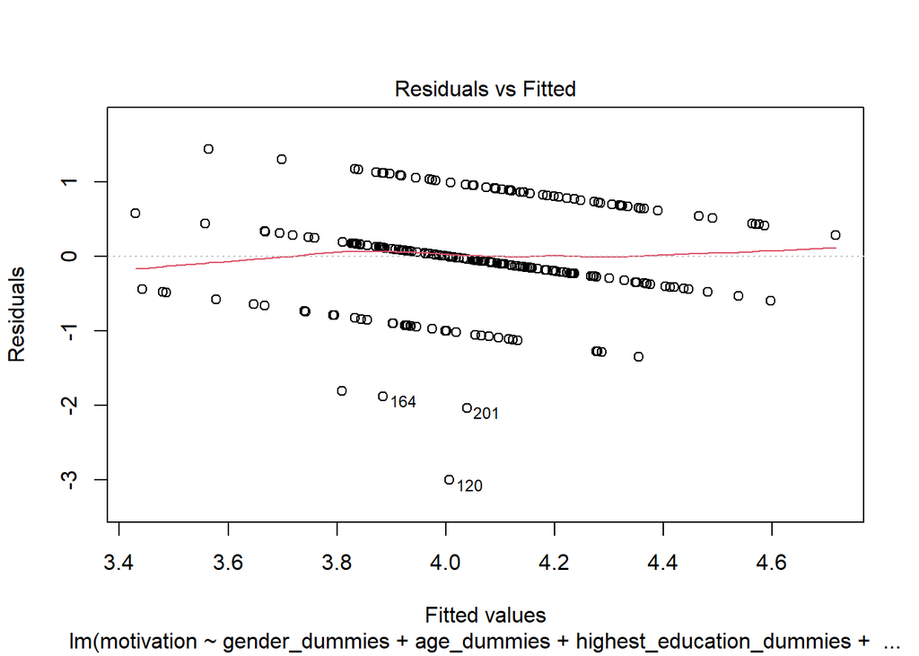

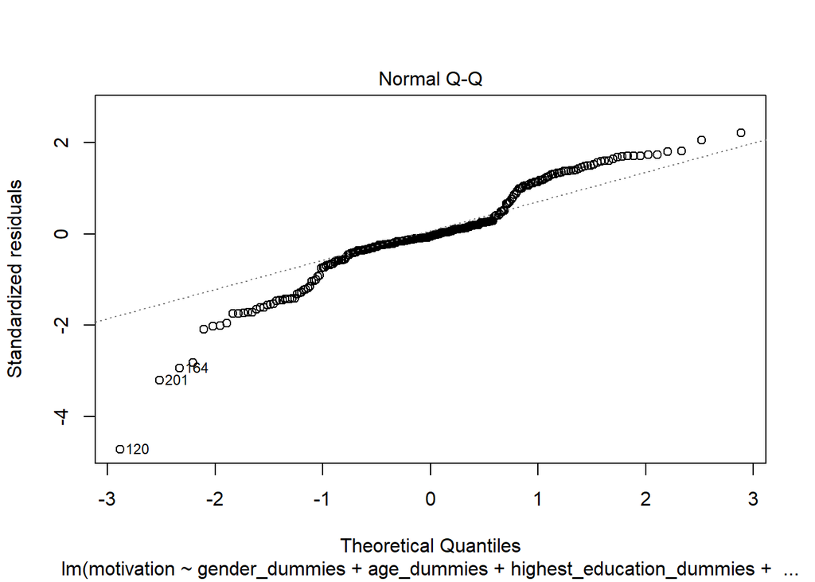

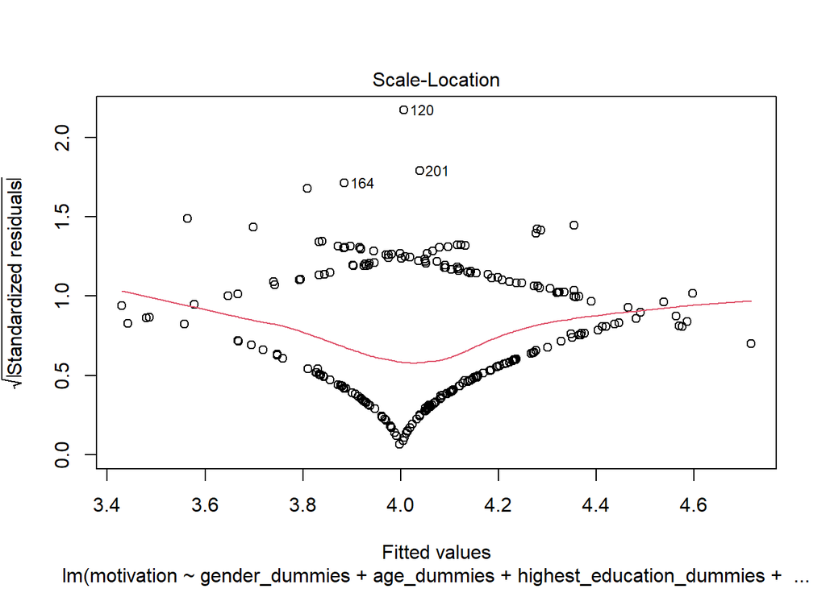

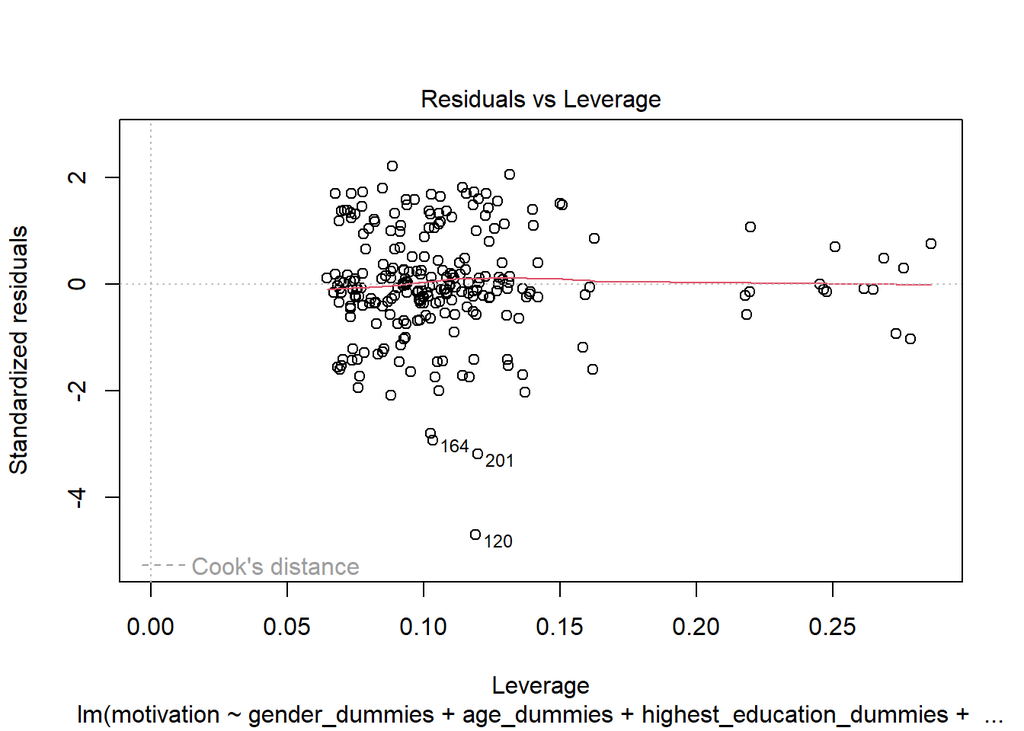

```r
# Check for linearity
plot(regression_model)
```

Does indeed seems linear.

```r
# Check for independence
dwtest(regression_model)
```

```
##
##  Durbin-Watson test
##
## data:  regression_model
## DW = 1.8978, p-value = 0.1161
## alternative hypothesis: true autocorrelation is greater than 0
```

```r
# Check for homoscedasticity
ncvTest(regression_model)
```

```
## Non-constant Variance Score Test
## Variance formula: ~ fitted.values
## Chisquare = 2.907161, Df = 1, p = 0.088187
```

```r
# Check for normality
shapiro.test(residuals(regression_model))
```

```
##
##  Shapiro-Wilk normality test
##
## data:  residuals(regression_model)
## W = 0.95219, p-value = 1.977e-07
```

```r
# Check for multicollinearity
vif(regression_model, type='predictor')
```

```
## GVIFs computed for predictors
```

|  | GVIF | Df | GVIF^(1/(2*Df)) | Interacts With | Other Predictors |
| --- | --- | --- | --- | --- | --- |
| gender_dummies | 1.552048 | 1 | 1.245812 | -- | age_dummies, highest_education_dummies, workexperience, vignette_dummies, control_type_dummies |
| age_dummies | 1.919106 | 3 | 1.114765 | -- | gender_dummies, highest_education_dummies, workexperience, vignette_dummies, control_type_dummies |
| highest_education_dummies | 1.530484 | 3 | 1.073507 | -- | gender_dummies, age_dummies, workexperience, vignette_dummies, control_type_dummies |
| workexperience | 1.479883 | 1 | 1.216504 | -- | gender_dummies, age_dummies, highest_education_dummies, vignette_dummies, control_type_dummies |
| vignette_dummies | 1.567604 | 19 | 1.011900 | control_type_dummies | gender_dummies, age_dummies, highest_education_dummies, workexperience |
| control_type_dummies | 1.567604 | 19 | 1.011900 | vignette_dummies | gender_dummies, age_dummies, highest_education_dummies, workexperience |

The GVIF values are lower than 5, emeaning that this check passes.

Even though not all of the assumptions hold, let us still have a look at the significance per variables in the model.

```r
summary(regression_model)
```

```
##
## Call:
## lm(formula = motivation ~ gender_dummies + age_dummies + highest_education_dummies +
##     workexperience + vignette_dummies * control_type_dummies,
##     data = regression_df)
##
## Residuals:
##      Min       1Q   Median       3Q      Max
## -3.00633 -0.23599 -0.03852  0.31833  1.43552
##
## Coefficients:
##                                                                                       Estimate
## (Intercept)                                                                           5.214004
## gender_dummies                                                                        0.096206
## age_dummiesdemographics.1.player.age25-34                                            -0.165538
## age_dummiesdemographics.1.player.age35-44                                            -0.119987
## age_dummiesdemographics.1.player.age45-54                                             0.005056
## highest_education_dummiesdemographics.1.player.highest_educationBachelors Degree     -0.609985
## highest_education_dummiesdemographics.1.player.highest_educationHigh School or lower -0.622067
## highest_education_dummiesdemographics.1.player.highest_educationMasters Degree       -0.443577
## workexperience                                                                       -0.090217
## vignette_dummiesvignette1                                                             0.104052
## vignette_dummiesvignette2                                                             0.235461
## vignette_dummiesvignette3                                                            -0.229583
## vignette_dummiesvignette4                                                            -0.017863
## control_type_dummiescontrol_typeautocontrol                                          -0.507035
## control_type_dummiescontrol_typecontrol                                              -0.012556
## control_type_dummiescontrol_typemonitoring                                            0.200720
## vignette_dummiesvignette1:control_type_dummiescontrol_typeautocontrol                 0.298892
## vignette_dummiesvignette2:control_type_dummiescontrol_typeautocontrol                 0.033882
## vignette_dummiesvignette3:control_type_dummiescontrol_typeautocontrol                 0.947464
## vignette_dummiesvignette4:control_type_dummiescontrol_typeautocontrol                 0.643665
## vignette_dummiesvignette1:control_type_dummiescontrol_typecontrol                    -0.102853
## vignette_dummiesvignette2:control_type_dummiescontrol_typecontrol                    -0.282701
## vignette_dummiesvignette3:control_type_dummiescontrol_typecontrol                     0.207624
## vignette_dummiesvignette4:control_type_dummiescontrol_typecontrol                    -0.002576
## vignette_dummiesvignette1:control_type_dummiescontrol_typemonitoring                 -0.379131
## vignette_dummiesvignette2:control_type_dummiescontrol_typemonitoring                 -0.528991
## vignette_dummiesvignette3:control_type_dummiescontrol_typemonitoring                 -0.035197
## vignette_dummiesvignette4:control_type_dummiescontrol_typemonitoring                 -0.320750
```

[output cut: 107 more lines]

```
## vignette_dummiesvignette4:control_type_dummiescontrol_typeautocontrol
## vignette_dummiesvignette1:control_type_dummiescontrol_typecontrol
## vignette_dummiesvignette2:control_type_dummiescontrol_typecontrol
## vignette_dummiesvignette3:control_type_dummiescontrol_typecontrol
## vignette_dummiesvignette4:control_type_dummiescontrol_typecontrol
## vignette_dummiesvignette1:control_type_dummiescontrol_typemonitoring
## vignette_dummiesvignette2:control_type_dummiescontrol_typemonitoring
## vignette_dummiesvignette3:control_type_dummiescontrol_typemonitoring
## vignette_dummiesvignette4:control_type_dummiescontrol_typemonitoring
## ---
## Signif. codes:  0 '***' 0.001 '**' 0.01 '*' 0.05 '.' 0.1 ' ' 1
##
## Residual standard error: 0.6797 on 227 degrees of freedom
## Multiple R-squared:  0.1035, Adjusted R-squared:  -0.003095
## F-statistic: 0.971 on 27 and 227 DF,  p-value: 0.5103
```

Among significant: the work experience (negative), and the combination of vignette 3 and automated control (positive); among those being close to significance – automated control (negative), bachelor’s degree (negative), high school or lower (negative).

Multiple R-squared: 0.1035, meaning that roughly 10% of the variation in motivation can be explained by the independent variables included in this model.

## Experiment 1 - students’ responses

Load experiment 1 data

```r
trust_students_df <- read.csv("data/trust_students.csv")
```

### Describe data

```r
ExpData(trust_students_df, type = 1)
```

| Descriptions | Value |
| --- | --- |
| Sample size (nrow) | 120 |
| No. of variables (ncol) | 89 |
| No. of numeric/interger variables | 40 |
| No. of factor variables | 0 |
| No. of text variables | 14 |
| No. of logical variables | 35 |
| No. of identifier variables | 7 |
| No. of date variables | 0 |
| No. of zero variance variables (uniform) | 25 |
| %. of variables having complete cases | 41.57% (37) |

[output cut: 3 more lines]

```r
ExpData(trust_students_df, type = 2)
```

| Index | Variable_Name | Variable_Type | Sample_n | Missing_Count | Per_of_Missing | No_of_distinct_values |
| --- | --- | --- | --- | --- | --- | --- |
| 1 | participant.id_in_session | integer | 120 | 0 | 0.000 | 120 |
| 2 | participant.code | character | 120 | 0 | 0.000 | 120 |
| 3 | participant.label | logical | 0 | 120 | 1.000 | 0 |
| 4 | participant._is_bot | integer | 120 | 0 | 0.000 | 1 |
| 5 | participant._index_in_pages | integer | 120 | 0 | 0.000 | 5 |
| 6 | participant._max_page_index | integer | 120 | 0 | 0.000 | 1 |
| 7 | participant._current_app_name | character | 40 | 80 | 0.667 | 4 |
| 8 | participant._current_page_name | character | 40 | 80 | 0.667 | 5 |
| 9 | participant.time_started_utc | character | 40 | 80 | 0.667 | 41 |
| 10 | participant.visited | integer | 120 | 0 | 0.000 | 2 |

[output cut: 79 more lines]

```r
ExpNumStat(trust_students_df, gp = "trust.1.group.minimum_amount", Outlier = TRUE, round = 2)
```

|  | Vname | Group | TN | nNeg | nZero | nPos | NegInf | PosInf | NA_Value | Per_of_Missing | sum | min | max | mean | median | SD | CV | IQR | Skewness | Kurtosis | LB.25% | UB.75% | nOutliers |
| --- | --- | --- | --- | --- | --- | --- | --- | --- | --- | --- | --- | --- | --- | --- | --- | --- | --- | --- | --- | --- | --- | --- | --- |
| 4 | demographics.1.player.id_in_group | All | 120 | 0 | 0 | 120 | 0 | 0 | 0 | 0 | 7260 | 1 | 120 | 60.50 | 60.5 | 34.79 | 0.57 | 59.50 | 0.00 | -1.20 | -58.50 | 179.50 | 0 |
| 9 | feedback.1.player.id_in_group | All | 120 | 0 | 0 | 120 | 0 | 0 | 0 | 0 | 7260 | 1 | 120 | 60.50 | 60.5 | 34.79 | 0.57 | 59.50 | 0.00 | -1.20 | -58.50 | 179.50 | 0 |
| 3 | informed_consent.1.player.id_in_group | All | 120 | 0 | 0 | 120 | 0 | 0 | 0 | 0 | 7260 | 1 | 120 | 60.50 | 60.5 | 34.79 | 0.57 | 59.50 | 0.00 | -1.20 | -58.50 | 179.50 | 0 |
| 5 | instructions_trust.1.player.id_in_group | All | 120 | 0 | 0 | 120 | 0 | 0 | 0 | 0 | 7260 | 1 | 120 | 60.50 | 60.5 | 34.79 | 0.57 | 59.50 | 0.00 | -1.20 | -58.50 | 179.50 | 0 |
| 1 | participant.id_in_session | All | 120 | 0 | 0 | 120 | 0 | 0 | 0 | 0 | 7260 | 1 | 120 | 60.50 | 60.5 | 34.79 | 0.57 | 59.50 | 0.00 | -1.20 | -58.50 | 179.50 | 0 |
| 2 | participant.payoff | All | 120 | 0 | 88 | 32 | 0 | 0 | 0 | 0 | 2510 | 0 | 120 | 20.92 | 0.0 | 37.60 | 1.80 | 40.00 | 1.48 | 0.59 | -60.00 | 100.00 | 4 |
| 10 | payment_info.1.player.id_in_group | All | 120 | 0 | 0 | 120 | 0 | 0 | 0 | 0 | 7260 | 1 | 120 | 60.50 | 60.5 | 34.79 | 0.57 | 59.50 | 0.00 | -1.20 | -58.50 | 179.50 | 0 |
| 8 | trust.1.group.id_in_subsession | All | 120 | 0 | 0 | 120 | 0 | 0 | 0 | 0 | 426 | 1 | 18 | 3.55 | 1.0 | 4.84 | 1.36 | 2.25 | 1.75 | 1.65 | -2.38 | 6.62 | 24 |
| 6 | trust.1.player.id_in_group | All | 120 | 0 | 0 | 120 | 0 | 0 | 0 | 0 | 6629 | 1 | 120 | 55.24 | 60.5 | 40.90 | 0.74 | 88.25 | -0.13 | -1.39 | -130.38 | 222.62 | 0 |
| 7 | trust.1.player.payoff | All | 120 | 0 | 88 | 32 | 0 | 0 | 0 | 0 | 2510 | 0 | 120 | 20.92 | 0.0 | 37.60 | 1.80 | 40.00 | 1.48 | 0.59 | -60.00 | 100.00 | 4 |

### Clean data

Remove all redundant rows with empty data

```r
trust_students_df <- trust_students_df %>% filter(trust.1.group.chosen_effort != "")
```

### Explore data

Plotting the categorical variables in the dataset

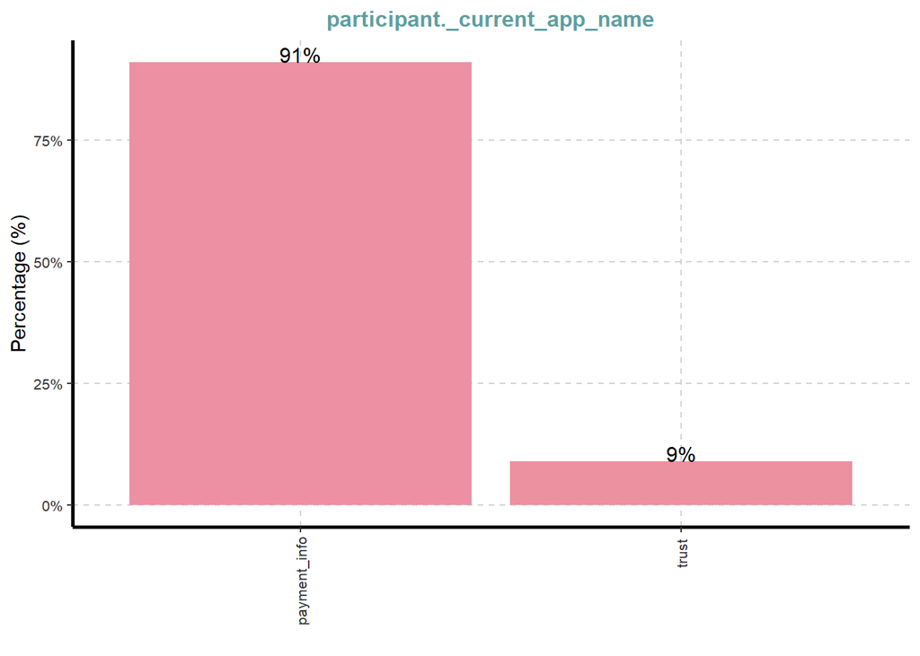

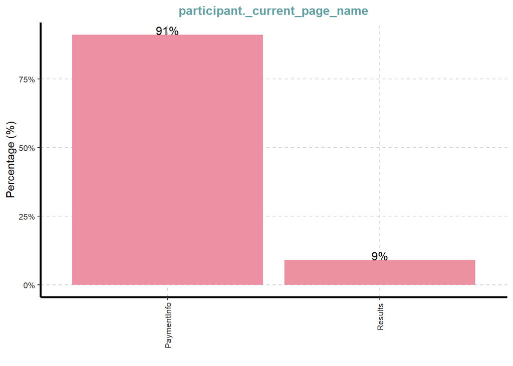

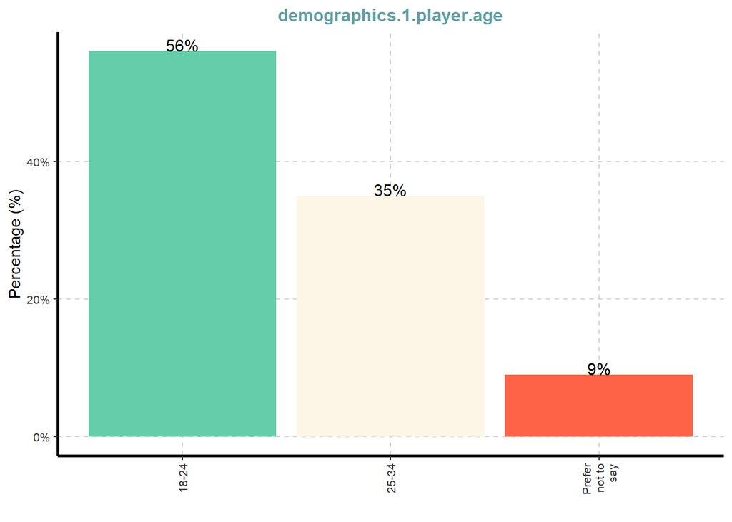

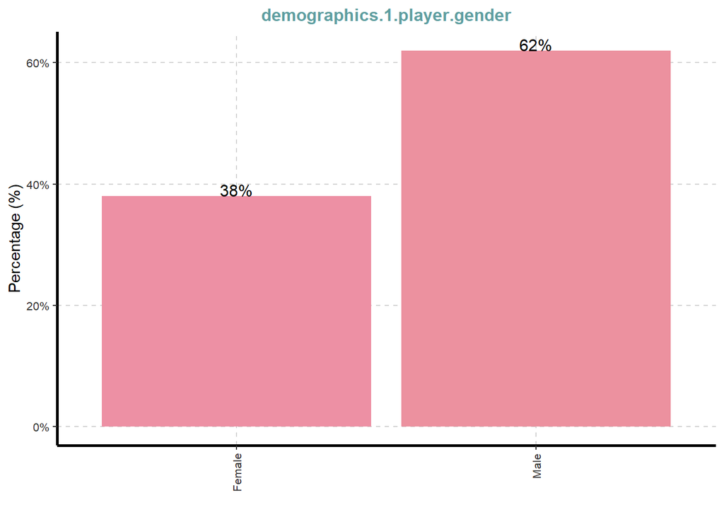

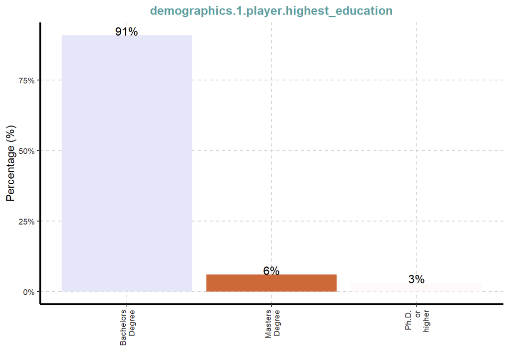

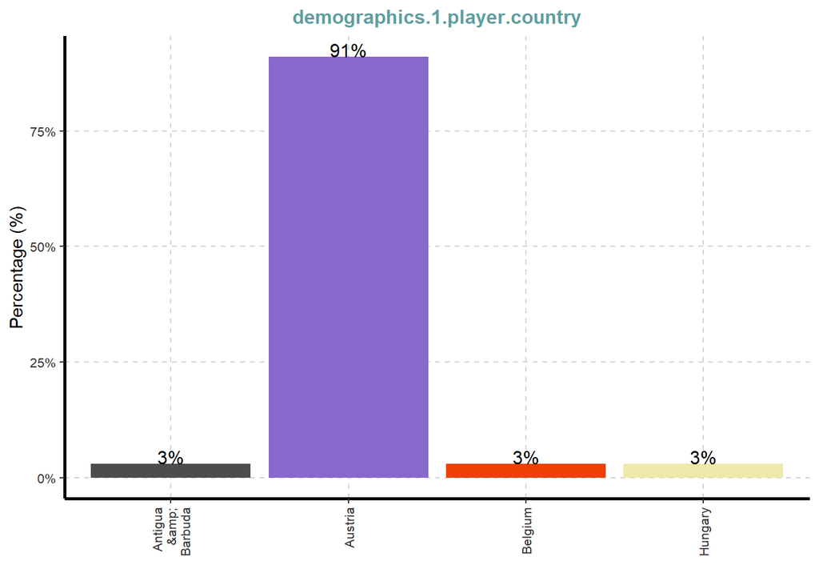

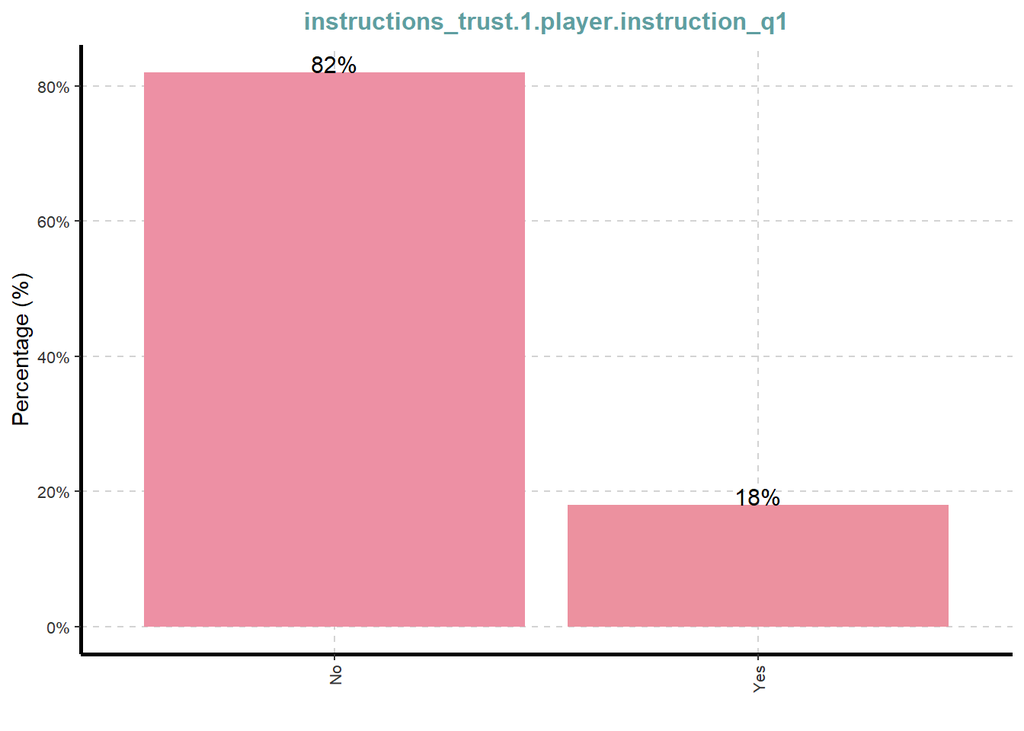

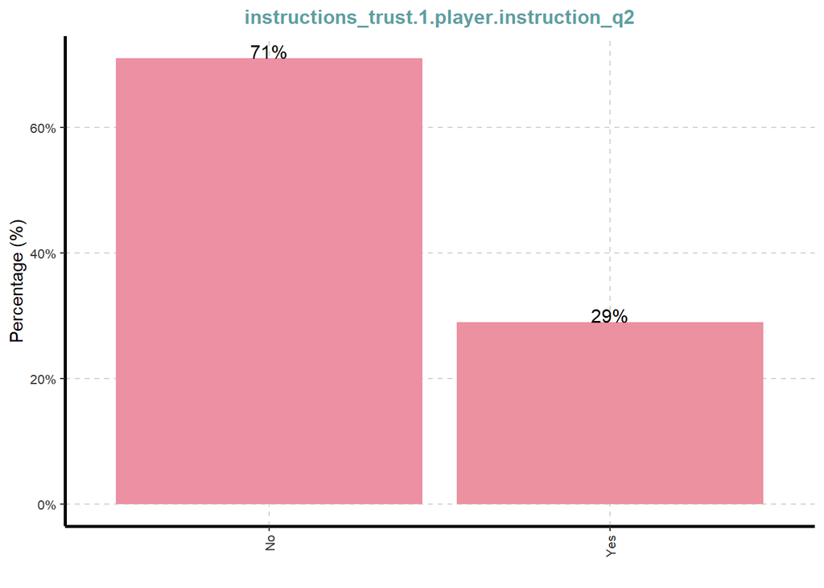

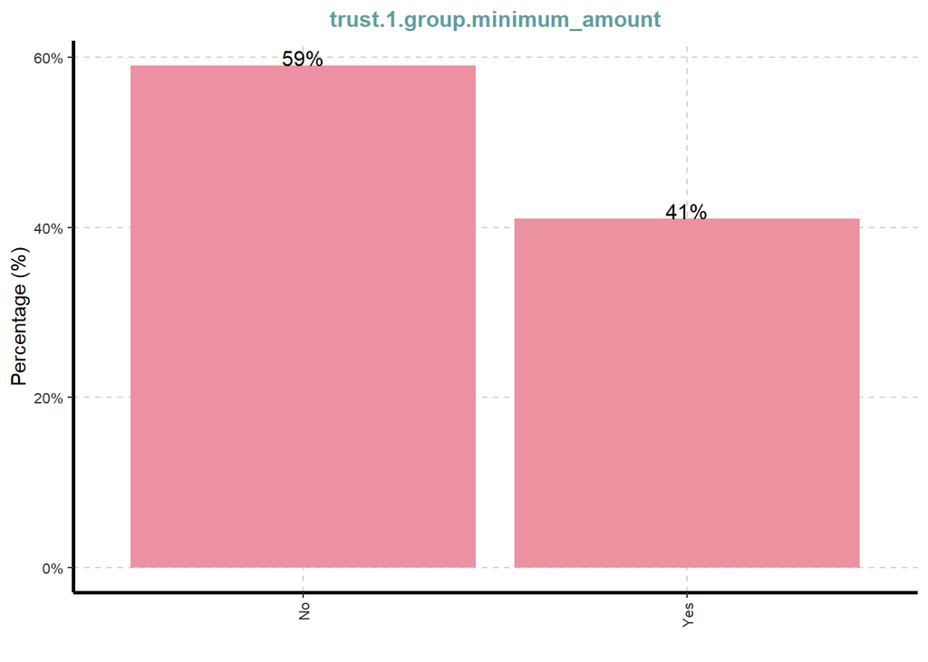

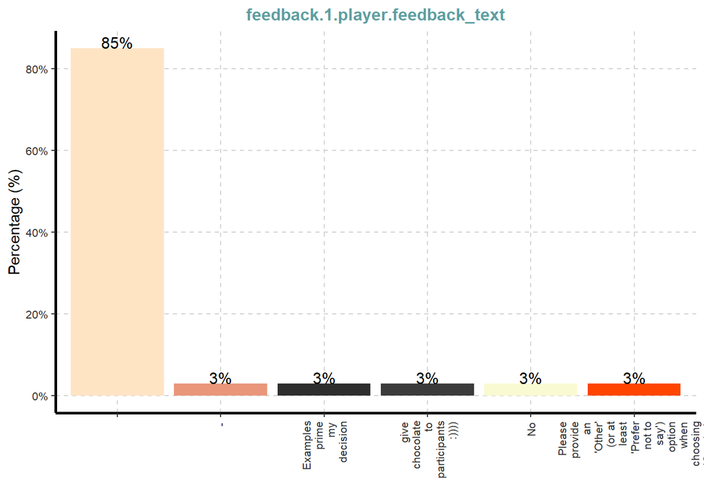

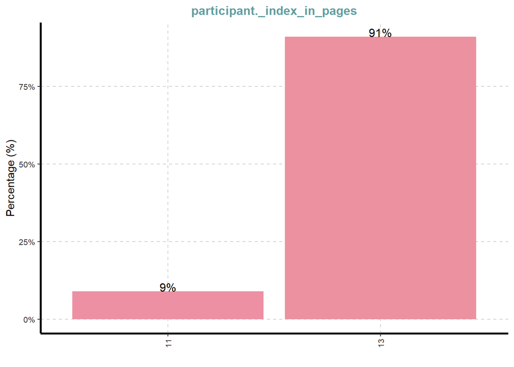

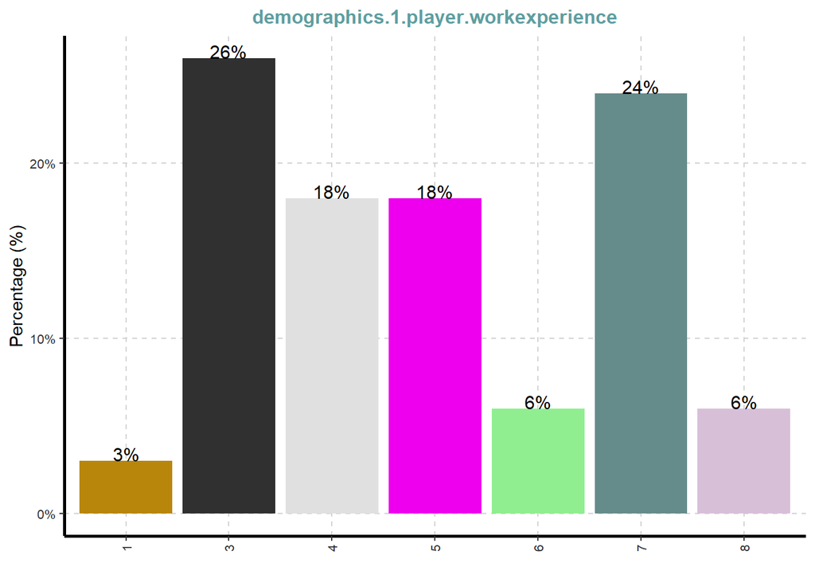

[5 more figures not shown]

```r
ExpCatViz(trust_students_df)
```

Some insight that can be drawn:

- male predominance in gender data.
- virtually all students from Austria.
- majority is of age 18-24.
- absolute majority has a bachelor’s degree.
- about 60% chose to trust.
- a lot of people with both a little and a lot of work experience.
- only one treatment in data (C20).

### Prepare data

Again, data duplicates info about effort provision.

```r
head(trust_students_df)
```

|  | participant.id_in_session | participant.code | participant.label | participant._is_bot | participant._index_in_pages | participant._max_page_index | participant._current_app_name | participant._current_page_name | participant.time_started_utc | participant.visited | participant.mturk_worker_id | participant.mturk_assignment_id | participant.payoff | participant.random_treatment_ids | session.code | session.label | session.mturk_HITId | session.mturk_HITGroupId | session.comment | session.is_demo | session.config.name | session.config.real_world_currency_per_point | session.config.participation_fee | session.params | informed_consent.1.player.id_in_group | informed_consent.1.player.role | informed_consent.1.player.payoff | informed_consent.1.player.consent_given | informed_consent.1.group.id_in_subsession | … |
| --- | --- | --- | --- | --- | --- | --- | --- | --- | --- | --- | --- | --- | --- | --- | --- | --- | --- | --- | --- | --- | --- | --- | --- | --- | --- | --- | --- | --- | --- | --- |
| 1 | 1 | n82jiw8c | NA | 0 | 13 | 13 | payment_info | PaymentInfo | 2023-01-11 08:35:10.015782 | 1 | NA | NA | 116 | NA | xfg6s7su | NA | NA | NA | NA | 0 | trust | 0.01 | 0.25 | NA | 1 | NA | 0 | 1 | 1 | … |
| 2 | 2 | yerw6e1l | NA | 0 | 11 | 13 | trust | Results | 2023-01-11 08:35:12.379148 | 1 | NA | NA | 40 | NA | xfg6s7su | NA | NA | NA | NA | 0 | trust | 0.01 | 0.25 | NA | 2 | NA | 0 | 1 | 1 | … |
| 3 | 3 | o9k4vlrw | NA | 0 | 13 | 13 | payment_info | PaymentInfo | 2023-01-11 08:35:15.224881 | 1 | NA | NA | 62 | NA | xfg6s7su | NA | NA | NA | NA | 0 | trust | 0.01 | 0.25 | NA | 3 | NA | 0 | 1 | 1 | … |
| 4 | 5 | iluhsmtb | NA | 0 | 13 | 13 | payment_info | PaymentInfo | 2023-01-11 08:45:36.230452 | 1 | NA | NA | 0 | NA | xfg6s7su | NA | NA | NA | NA | 0 | trust | 0.01 | 0.25 | NA | 5 | NA | 0 | 1 | 1 | … |
| 5 | 6 | pqmdqj2v | NA | 0 | 13 | 13 | payment_info | PaymentInfo | 2023-01-11 08:45:36.755433 | 1 | NA | NA | 100 | NA | xfg6s7su | NA | NA | NA | NA | 0 | trust | 0.01 | 0.25 | NA | 6 | NA | 0 | 1 | 1 | … |
| 6 | 7 | qd06m7gh | NA | 0 | 13 | 13 | payment_info | PaymentInfo | 2023-01-11 08:45:37.453026 | 1 | NA | NA | 42 | NA | xfg6s7su | NA | NA | NA | NA | 0 | trust | 0.01 | 0.25 | NA | 7 | NA | 0 | 1 | 1 | … |

```r
trust_students_c20 <- trust_students_df %>%
  filter(participant.id_in_session %% 2 == 0)
```

### Analysis

In this section we will be aiming to conduct several tests to understand if hidden costs of control are present in the results of the this experiment. The significance level $\alpha$ here and further on is chosen to be 5%.

Again, we will test if there is difference in effort provision in cases of controlling and not controlling, with the null hypothesis being that the groups are the same. This will be done by modifying chosen effort in no control scenario to always be above minimum amount (setting all those that are lower to a minimum amount).

```r
trust_students_c20 <- trust_students_c20 %>%
  mutate(trust.1.group.chosen_effort_modified = ifelse(trust.1.group.chosen_effort < 20, 20, trust.1.group.chosen_effort))

wilcox.test(trust_students_c20$trust.1.group.chosen_effort_min20, trust_students_c20$trust.1.group.chosen_effort_modified, paired = T, exact = F)
```

```
##
##  Wilcoxon signed rank test with continuity correction
##
## data:  trust_students_c20$trust.1.group.chosen_effort_min20 and trust_students_c20$trust.1.group.chosen_effort_modified
## V = 1.5, p-value = 0.01463
## alternative hypothesis: true location shift is not equal to 0
```

Let’s look at the means of groups.

```r
mean(trust_students_c20$trust.1.group.chosen_effort_min20)
```

```
## [1] 27
```

```r
mean(trust_students_c20$trust.1.group.chosen_effort_modified)
```

```
## [1] 35.0625
```

As expected, mean effort provision for not control is higher.

Now, let us conduct the second test for this treatment. We will be testing if the hidden costs of control outweigh the benefits. That is, if effort provision is greater for no control situations even if no adjustment with setting values lesser than minimum amount to minimum amount is implemented.

```r
wilcox.test(trust_students_c20$trust.1.group.chosen_effort_min20, trust_students_c20$trust.1.group.chosen_effort, paired = T, exact = F)
```

```
##
##  Wilcoxon signed rank test with continuity correction
##
## data:  trust_students_c20$trust.1.group.chosen_effort_min20 and trust_students_c20$trust.1.group.chosen_effort
## V = 25.5, p-value = 0.3031
## alternative hypothesis: true location shift is not equal to 0
```

This test yields no significant results, which is in line with Falk & Kosfeld’s findings – the economic incentives start outweighing the hidden costs of control after a certain threshold of minimal amount that can be set by the principal.

The means and medians of these groups:

```r
mean(trust_students_c20$trust.1.group.chosen_effort_min20)
```

```
## [1] 27
```

```r
mean(trust_students_c20$trust.1.group.chosen_effort)
```

```
## [1] 31.3125
```

```r
median(trust_students_c20$trust.1.group.chosen_effort_min20)
```

```
## [1] 20
```

```r
median(trust_students_c20$trust.1.group.chosen_effort)
```

```
## [1] 30
```

Interestingly, the value for the medians in case principal controls and trusts is equal to those reported by Falk & Kosfeld – 20 and 30, respectively.

The last analysis of the results of this experiment aim to assess the heterogeneity of the agents of all treatments. All agents were presented with a choice to enter the effort level for both cases - no control and with control, meaning that they could either react negatively to control (effort with control is less than without), neutrally (the effort value is the same) or positively (effort with control is greater than without).

```r
sum(trust_students_c20$trust.1.group.chosen_effort > trust_students_c20$trust.1.group.chosen_effort_min20, na.rm=TRUE)/nrow(trust_students_c20)
```

```
## [1] 0.5
```

```r
sum(trust_students_c20$trust.1.group.chosen_effort == trust_students_c20$trust.1.group.chosen_effort_min20, na.rm=TRUE)/nrow(trust_students_c20)
```

```
## [1] 0.25
```

```r
sum(trust_students_c20$trust.1.group.chosen_effort < trust_students_c20$trust.1.group.chosen_effort_min20, na.rm=TRUE)/nrow(trust_students_c20)
```

```
## [1] 0.25
```

As depicted, the group of agent reacting negatively to control is the majority (50%). It is they, who are responsible for the existence of hidden costs of control, and because of them, on average, it does not pay off for the principle to control their agent. To compare, Falk & Kosfeld’s experiment finds that 42% of agents react negatively, 21% react neutrally and 37% react positively.